# Single-species occupancy models

Ken Kellner

# Outline

1. Introduction
2. Simulate dataset
3. Fit in `unmarked`
4. Fit in `nimble`
5. Other methods

# Introduction

The probability a species occupies (is present at) a site ($\psi$)

A key consideration of species distribution models (SDMs)

Problem: detection is imperfect (*p* < 1)

Just because we don't detect a species at a site doesn't mean it isn't there

Solution: **Repeated samples**

Visiting the site multiple times allows estimation of detection probability *p* and thus correction of $\psi$

[figure not shown]

## State (occupancy) process

**Parameters**

$z_i$: Latent occupancy at site $i$

$\psi_i$: Occupancy probability at site $i$

**Math**

$$z_i \sim \mathrm{Bernoulli}(\psi_i)$$

Equivalent to:

$$z_i \sim \mathrm{Binomial}(1, \psi_i)$$

## Detection process

**Parameters/data**

$y_{ij}$: Observed detection at site $i$ for repeated sample $j$

$p_{ij}$: Probability of detecting an individual at site $i$ in sample $j$

**Math**

$$y_{ij} \sim \mathrm{Bernoulli}(p_{ij} \cdot z_i)$$

## Key assumptions

- Population is closed during the repeated samples
- Repeated samples are independent
- No false positive detections (only false negative)

# Simulate a dataset

Example adapted from Kéry and Kellner, *Applied Statistical Modelling for Ecologists* (2024)

[figure not shown]

Occupancy of plant (gentian) at a series of sites

Both occupancy and detection depend on humidity

[figure not shown]

**Study design and covariates**

```r
set.seed(123)
nsites <- 150
nvisits <- 3
humidity <- runif(nsites, -1, 1)
```

**Occupancy parameters**

$occ_{int}$: The occupancy intercept

$occ_{hum}$: The effect of humidity on occupancy

```r
occ_int <- 0
occ_hum <- 2
```

**Simulate occupancy at each site**

$$\mu_{occ_i} = \mathrm{occ}_{int} + \mathrm{occ}_{hum} \cdot \mathrm{humidity_i} $$ $$ \psi_i = \mathrm{ilogit}(\mu_{occ_i}) $$

```r
mu_occ <- occ_int + occ_hum * humidity
psi <- plogis(mu_occ)
```

Plot the relationship:

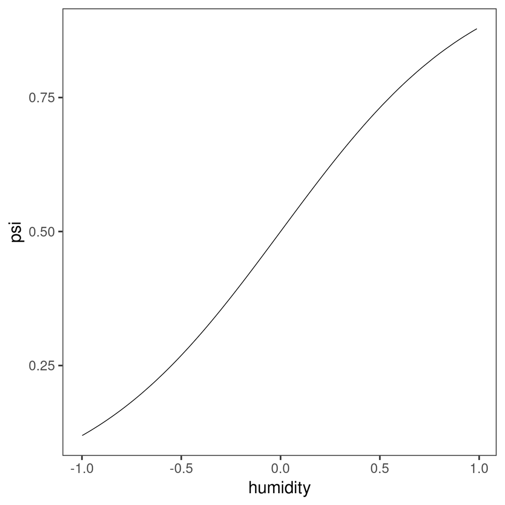

```r
plot_psi <- data.frame(humidity=humidity, est=psi)
plot_psi <- plot_psi[order(humidity),]

library(ggplot2)
options(repr.plot.width=10, repr.plot.height=10)

ggplot(data=plot_psi, aes(x=humidity, y=est)) +
  theme_bw(base_size=24) +
  theme(panel.grid = element_blank()) +
  geom_line() +
  labs(y = "psi")
```

Simulate the latent occupancy state:

$$ z_i \sim \mathrm{Bernoulli}(\psi_i) $$

```r
z <- rbinom(nsites, 1, p = psi)
z
```

1. 1

2. 1

3. 0

4. 1

5. 1

6. 0

7. 0

8. 1

9. 1

10. 0

11. 1

12. 0

13. 1

14. 1

15. 0

16. 1

17. 1

18. 0

19. 0

20. 1

21. 1

22. 1

23. 0

24. 1

25. 0

26. 1

27. 1

28. 1

29. 1

30. 0

31. 1

32. 1

33. 0

34. 1

35. 0

36. 0

37. 1

38. 0

39. 1

40. 1

41. 0

42. 0

43. 1

44. 0

45. 1

46. 0

47. 0

48. 1

49. 0

50. 1

51. 0

52. 1

53. 1

54. 0

55. 1

56. 1

57. 0

58. 1

59. 1

60. 0

61. 1

62. 0

63. 0

64. 0

65. 1

66. 1

67. 1

68. 1

69. 0

70. 1

71. 1

72. 0

73. 0

74. 0

75. 0

76. 0

77. 0

78. 1

79. 1

80. 1

81. 0

82. 1

83. 0

84. 1

85. 0

86. 0

87. 1

88. 0

89. 1

90. 1

91. 0

92. 0

93. 0

94. 1

95. 0

96. 0

97. 1

98. 1

99. 1

100. 0

101. 1

102. 0

103. 1

104. 1

105. 1

106. 1

107. 1

108. 1

109. 0

110. 1

111. 0

112. 1

113. 0

114. 0

115. 1

116. 0

117. 1

118. 1

119. 1

120. 0

121. 0

122. 0

123. 0

124. 0

125. 1

126. 1

127. 1

128. 0

129. 0

130. 1

131. 0

132. 1

133. 1

134. 1

135. 1

136. 1

137. 1

138. 1

139. 1

140. 1

141. 0

142. 0

143. 0

144. 1

145. 1

146. 1

147. 1

148. 0

149. 0

150. 0

Plot the raw latent occupancy data:

```r
breaks <- quantile(humidity, c(0, 0.2, 0.4, 0.6, 0.8, 1))
hum_cat <- cut(humidity, breaks = breaks)
tab <- aggregate(z ~ hum_cat, FUN=mean)
tab$n <- table(hum_cat)
tab$se <- sqrt(tab[,2] * (1-tab[,2]) / tab$n)
```

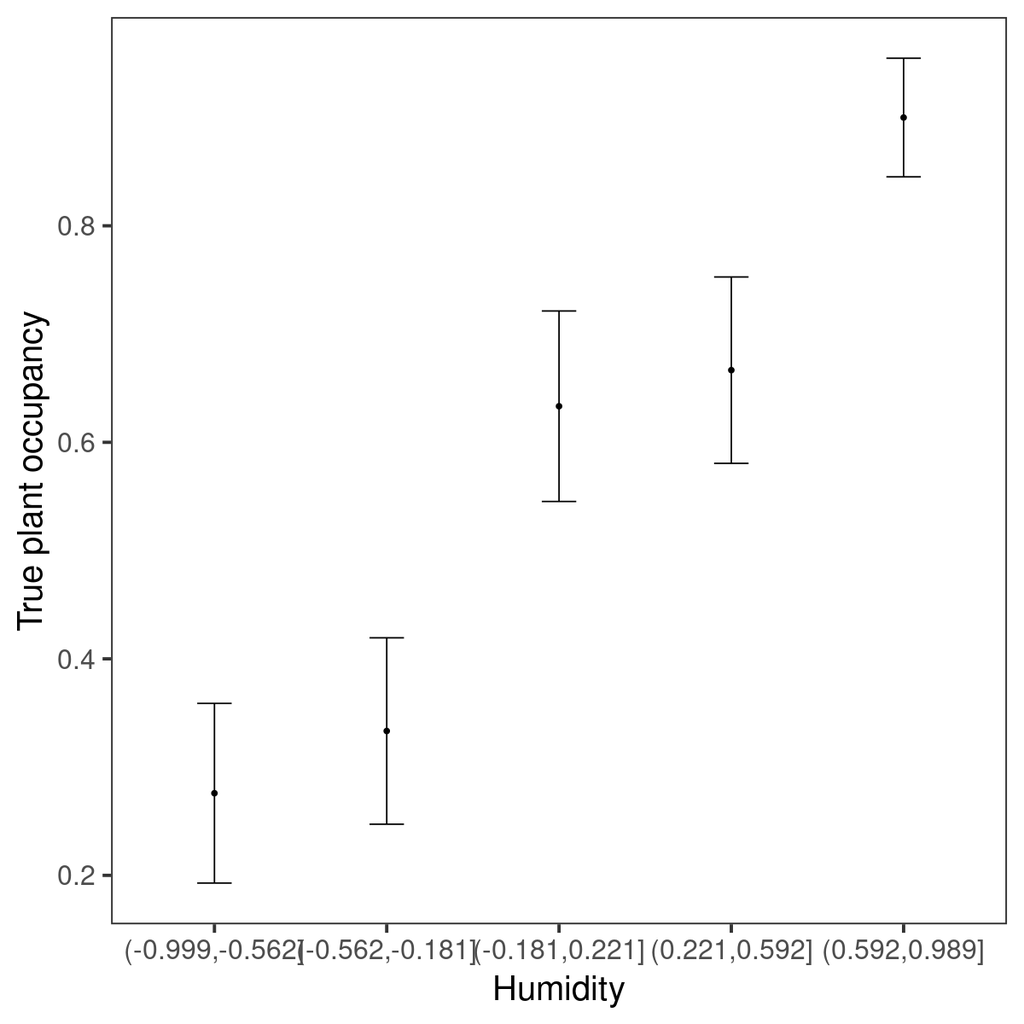

```r
ggplot(data = tab) +
  geom_point(aes(x=hum_cat, y = z)) +
  geom_errorbar(aes(x = hum_cat, ymin= z - se, ymax=z + se), width=0.2) +
  labs(y = "True plant occupancy", x = "Humidity") +
  theme_bw(base_size = 24) +
  theme(panel.grid = element_blank())
```

**Detection parameters**

$det_{int}$: The detection intercept

$det_{hum}$: The effect of humidity on detection

```r
det_int <- 0
det_hum <- -3
truth <- c(occ_int = occ_int, occ_hum = occ_hum, det_int = det_int, det_hum = det_hum)
```

Note that humidity has oppposite effects on occupancy (2) and detection (-3)! A "pathological" example.

**Simulate detection process**

$$\mu_{det_i} = \mathrm{det}_{int} + \mathrm{det}_{hum} \cdot \mathrm{humidity_i} $$ $$ p_i = \mathrm{ilogit}(\mu_{det_i}) $$

```r
mu_det <- det_int + det_hum * humidity
p <- plogis(mu_det)
```

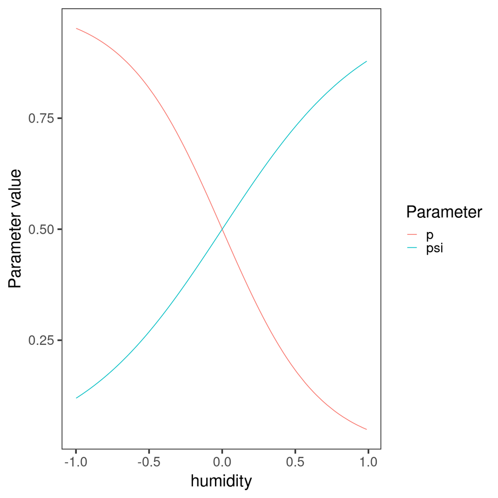

```r
plot_p <- data.frame(humidity=humidity, est=p)
plot_p <- plot_p[order(humidity),]

plot_psi$param <- "psi"
plot_p$param <- "p"
plot_dat <- rbind(plot_psi, plot_p)

ggplot(data=plot_dat) +
  theme_bw(base_size=24) +
  theme(panel.grid = element_blank()) +
  geom_line(aes(x=humidity, y=est, col=param)) +
  labs(y="Parameter value", col="Parameter")
```

Simulate observed detection/non-detection:

$$ y_{ij} \sim \mathrm{Bernoulli}(p_{i} \cdot z_i) $$

```r
y <- matrix(NA, nsites, nvisits)

for (i in 1:nsites){
  for (j in 1:nvisits){
    y[i,j] <- rbinom(1, 1, p = p[i] * z[i])
  }
}
```

```r
head(y)
```

A matrix: 6 × 3 of type int

| 0 | 1 | 1 |
| --- | --- | --- |
| 0 | 0 | 0 |
| 0 | 0 | 0 |
| 0 | 0 | 0 |
| 0 | 0 | 0 |
| 0 | 0 | 0 |

**Plot observed detection/non-detection as a function of humidity**

First determine if gentian was observed at least once at each site:

```r
y_naive <- apply(y, 1, max) # ever observed
```

Next bin `y_naive` and plot the same way we did with `z` earlier:

```r
breaks <- quantile(humidity, c(0, 0.2, 0.4, 0.6, 0.8, 1))
hum_cat <- cut(humidity, breaks = breaks)
tab <- aggregate(y_naive ~ hum_cat, FUN=mean)
tab$n <- table(hum_cat)
tab$se <- sqrt(tab[,2] * (1-tab[,2]) / tab$n)
```

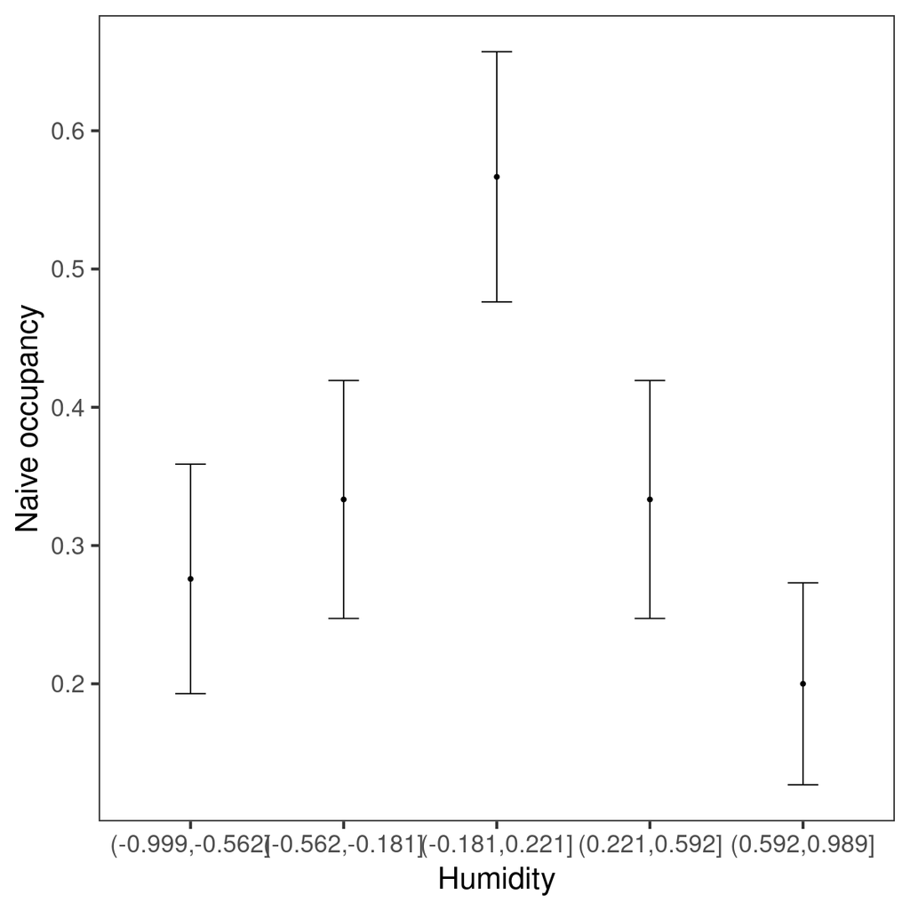

```r
ggplot(data = tab) +
  geom_point(aes(x=hum_cat, y = y_naive)) +
  geom_errorbar(aes(x = hum_cat, ymin= y_naive - se, ymax=y_naive + se), width=0.2) +
  labs(y = "Naive occupancy", x = "Humidity") +
  theme_bw(base_size = 24) +
  theme(panel.grid = element_blank())
```

### Naive analysis

Fit a standard logistic regression, ignoring imperfect detection

```r
fit_glm <- glm(y_naive~humidity, family=binomial)
glm_est <- c(coef(fit_glm), NA, NA)
summary(fit_glm)
```

```
Call:
glm(formula = y_naive ~ humidity, family = binomial)

Coefficients:
            Estimate Std. Error z value Pr(>|z|)
(Intercept)  -0.6631     0.1725  -3.845 0.000121 ***
humidity     -0.1292     0.3017  -0.428 0.668524
---
Signif. codes:  0 ‘***’ 0.001 ‘**’ 0.01 ‘*’ 0.05 ‘.’ 0.1 ‘ ’ 1

(Dispersion parameter for binomial family taken to be 1)

    Null deviance: 192.31  on 149  degrees of freedom
Residual deviance: 192.13  on 148  degrees of freedom
AIC: 196.13

Number of Fisher Scoring iterations: 4
```

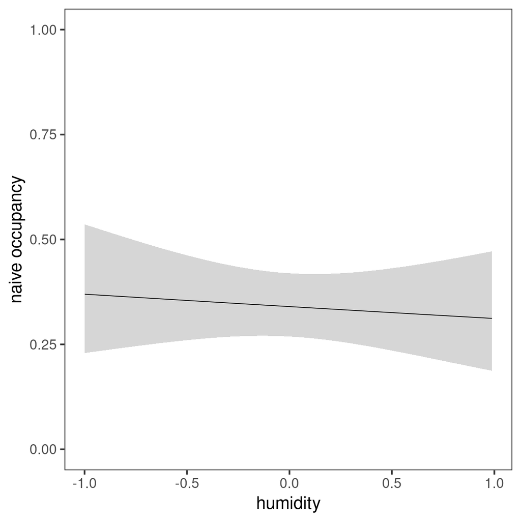

```r
nd <- data.frame(humidity = sort(humidity))
mod_est <- predict(fit_glm, newdata=nd, se.fit=TRUE)

nd$est <- plogis(mod_est$fit)
nd$lower <- plogis(mod_est$fit - 1.96*mod_est$se.fit)
nd$upper <- plogis(mod_est$fit + 1.96*mod_est$se.fit)

ggplot(data=nd, aes(x=humidity, y=est)) +
  geom_ribbon(aes(ymin=lower, ymax=upper), alpha=0.2) +
  geom_line() +
  theme_bw(base_size=24) +
  theme(panel.grid=element_blank()) +
  ylim(0, 1) +
  labs(y="naive occupancy")
```

```r
fit_glm2 <- glm(y_naive~humidity+I(humidity^2), family=binomial)
summary(fit_glm2)
```

```
Call:
glm(formula = y_naive ~ humidity + I(humidity^2), family = binomial)

Coefficients:
              Estimate Std. Error z value Pr(>|z|)
(Intercept)    0.01687    0.25682   0.066  0.94761
humidity      -0.07690    0.35398  -0.217  0.82801
I(humidity^2) -2.32046    0.71163  -3.261  0.00111 **
---
Signif. codes:  0 ‘***’ 0.001 ‘**’ 0.01 ‘*’ 0.05 ‘.’ 0.1 ‘ ’ 1

(Dispersion parameter for binomial family taken to be 1)

    Null deviance: 192.31  on 149  degrees of freedom
Residual deviance: 179.72  on 147  degrees of freedom
AIC: 185.72

Number of Fisher Scoring iterations: 4
```

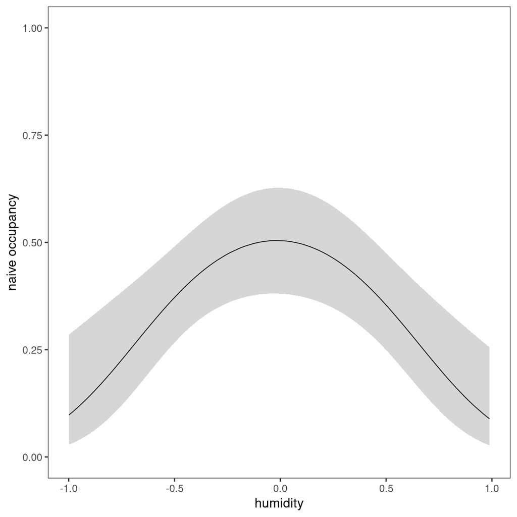

```r
nd <- data.frame(humidity = sort(humidity))
mod_est <- predict(fit_glm2, newdata=nd, se.fit=TRUE)

nd$est <- plogis(mod_est$fit)
nd$lower <- plogis(mod_est$fit - 1.96*mod_est$se.fit)
nd$upper <- plogis(mod_est$fit + 1.96*mod_est$se.fit)

ggplot(data=nd, aes(x=humidity, y=est)) +
  geom_ribbon(aes(ymin=lower, ymax=upper), alpha=0.2) +
  geom_line() +
  theme_bw(base_size=18) +
  theme(panel.grid=element_blank()) +
  ylim(0, 1) +
  labs(y="naive occupancy")
```

Both analyses capture the wrong pattern (actually measuring $\psi \cdot p$)

# Fit in R: `unmarked`

- A package for fitting a wide variety of occupancy and abundance models, accounting for imperfect detection
- Uses maximum likelihood

```r
library(unmarked)
```

## Organize data

Using an `unmarkedFrame`, analogous to an R data frame

Components:

- observed data `y`
- site covariates `siteCovs`
- obs covariates `obsCovs`

```r
umf <- unmarkedFrameOccu(y = y, siteCovs = data.frame(humidity = humidity))
head(umf)
```

```
Data frame representation of unmarkedFrame object.
   y.1 y.2 y.3    humidity
1    0   1   1 -0.42484496
2    0   0   0  0.57661027
3    0   0   0 -0.18204616
4    0   0   0  0.76603481
5    0   0   0  0.88093457
6    0   0   0 -0.90888700
7    0   0   0  0.05621098
8    0   0   0  0.78483809
9    1   1   0  0.10287003
10   0   0   0 -0.08677053
```

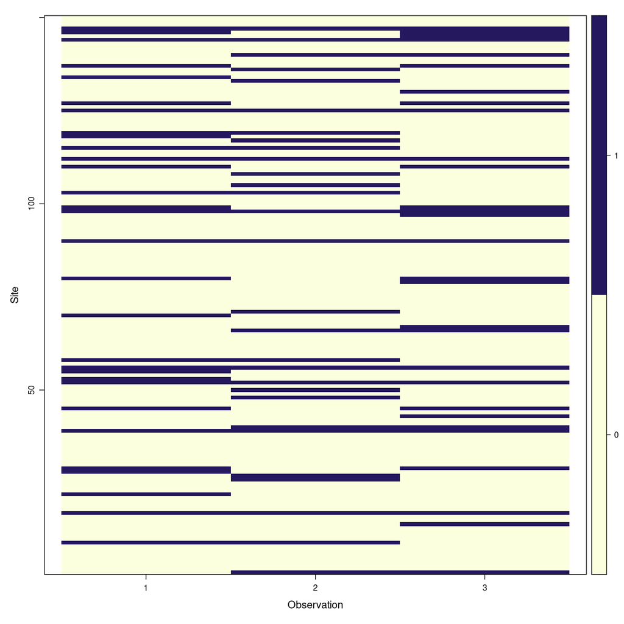

```r
plot(umf)
```

## Fit the model

Using the `occu` function

Need to specify a "double" formula: first detection, then occupancy

`~humidity ~humidity`

```r
fit_unm <- occu(~humidity ~humidity, data = umf)
```

```r
summary(fit_unm)
```

```
Call:
occu(formula = ~humidity ~ humidity, data = umf)

Occupancy (logit-scale):
            Estimate    SE    z P(>|z|)
(Intercept)    0.457 0.389 1.17 0.24014
humidity       2.181 0.760 2.87 0.00412

Detection (logit-scale):
            Estimate    SE     z  P(>|z|)
(Intercept)   -0.228 0.206 -1.11 2.69e-01
humidity      -2.844 0.387 -7.34 2.13e-13

AIC: 356.454
Number of sites: 150
optim convergence code: 0
optim iterations: 35
Bootstrap iterations: 0
```

## Model fit

Residuals:

$$ r_{ij} = (y_{ij} - \hat{y}_{ij}) $$

$$\hat{y}_{ij} = \psi_i p_{ij} $$

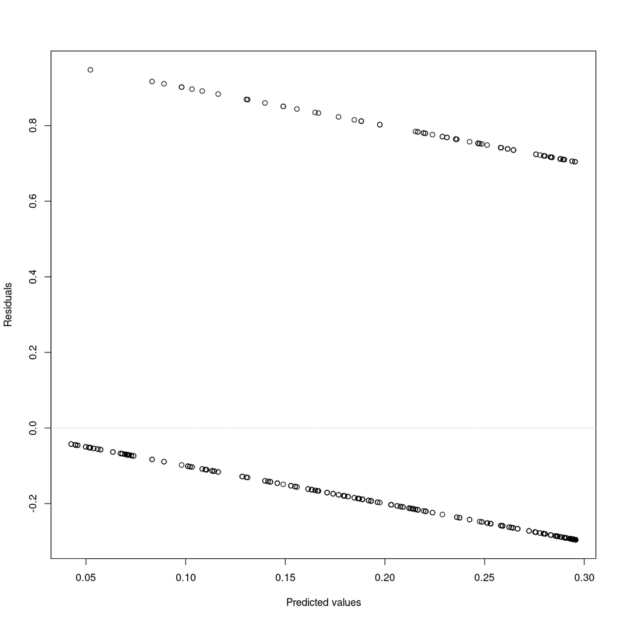

```r
plot(fit_unm)
```

### Check model fit with parametric bootstrap

1. Calculate test statistic using fitted model and real dataset
2. Simulate new datasets based on model
3. Fit models to new datasets
4. Calculate test statistics using new datasets/models
1. Basic test statistic: sum of squared errors (SSE)

$$ \mathrm{SSE} = \sum{r_{ij}^2} $$

```r
SSE(fit_unm)
```

**SSE:** 67.8770106370044

2. We can simulate new datasets using `simulate`

```r
new_datasets <- simulate(fit_unm, 2)
lapply(new_datasets, head)
```

1. A matrix: 6 × 3 of type dbl

   | 0 | 0 | 0 |
   | --- | --- | --- |
   | 0 | 0 | 0 |
   | 0 | 0 | 0 |
   | 0 | 0 | 0 |
   | 0 | 0 | 0 |
   | 0 | 0 | 0 |

2. A matrix: 6 × 3 of type dbl

   | 1 | 0 | 0 |
   | --- | --- | --- |
   | 0 | 0 | 0 |
   | 0 | 0 | 0 |
   | 0 | 0 | 0 |
   | 0 | 0 | 0 |
   | 1 | 1 | 1 |

3-4: We could fit the model to each new dataset manually, but `parboot` does it for us:

```r
pb <- parboot(fit_unm, nsim = 30)
```

```
Call: parboot(object = fit_unm, nsim = 30)

Parametric Bootstrap Statistics:
      t0 mean(t0 - t_B) StdDev(t0 - t_B) Pr(t_B > t0)
SSE 67.9           1.98             7.43        0.452

t_B quantiles:
     0% 2.5% 25% 50% 75% 97.5% 100%
[1,] 47   47  64  68  70    77   78

t0 = Original statistic computed from data
t_B = Vector of bootstrap samples
```

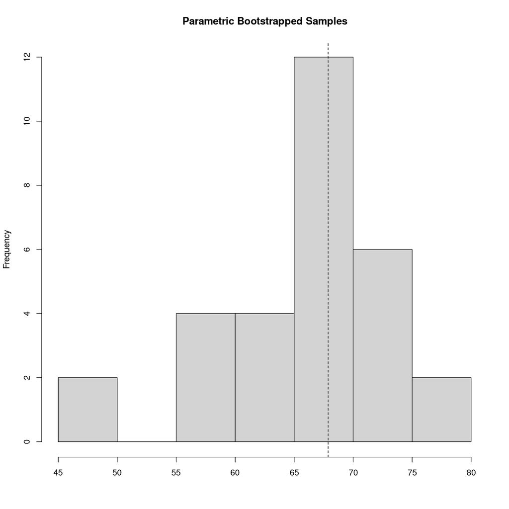

```r
plot(pb)
pb
```

### An alternative fit statistic

The MacKenzie-Bailey chi-square (MacKenzie & Bailey, 2004)

```r
library(AICcmodavg)

mb.chisq(fit_unm)
```

```
MacKenzie and Bailey goodness-of-fit for single-season occupancy model

Pearson chi-square table:

    Cohort Observed Expected Chi-square
000      0       99    99.45       0.00
001      0        7     7.98       0.12
010      0       10     7.98       0.51
011      0        4     5.30       0.32
100      0        7     7.98       0.12
101      0        8     5.30       1.37
110      0        5     5.30       0.02
111      0       10    10.69       0.04

Chi-square statistic = 2.5068
```

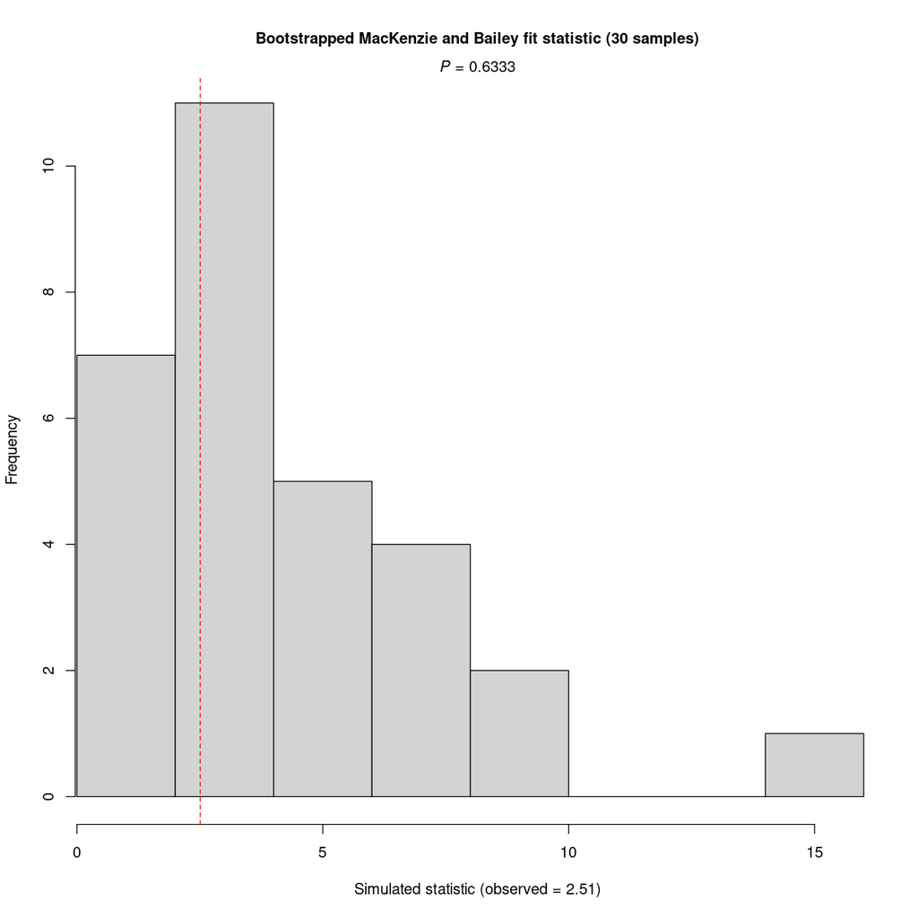

```r
mb_test <- mb.gof.test(fit_unm, nsim=30)
```

## Inference

```r
summary(fit_unm)
```

```
Call:
occu(formula = ~humidity ~ humidity, data = umf)

Occupancy (logit-scale):
            Estimate    SE    z P(>|z|)
(Intercept)    0.457 0.389 1.17 0.24014
humidity       2.181 0.760 2.87 0.00412

Detection (logit-scale):
            Estimate    SE     z  P(>|z|)
(Intercept)   -0.228 0.206 -1.11 2.69e-01
humidity      -2.844 0.387 -7.34 2.13e-13

AIC: 356.454
Number of sites: 150
optim convergence code: 0
optim iterations: 35
Bootstrap iterations: 0
```

### Compare with truth

```r
unm_est  <- coef(fit_unm)

comp <- cbind(truth = truth, glm = glm_est, unm = unm_est)
round(comp, 3)
```

A matrix: 4 × 3 of type dbl

|  | truth | glm | unm |
| --- | --- | --- | --- |
| occ_int | 0 | -0.663 | 0.457 |
| occ_hum | 2 | -0.129 | 2.181 |
| det_int | 0 | NA | -0.228 |
| det_hum | -3 | NA | -2.844 |

```r
plogis(0)
plogis(0.457)
```

0.5

0.612302251912714

### Get parameter estimates for each site

Use `predict`!

For $\psi$:

```r
psi_site <- predict(fit_unm, type = "state")
head(psi_site)
```

A data.frame: 6 × 4

|  | Predicted <dbl> | SE <dbl> | lower <dbl> | upper <dbl> |
| --- | --- | --- | --- | --- |
| 1 | 0.3847622 | 0.05853732 | 0.27807053 | 0.5038214 |
| 2 | 0.8474621 | 0.10079478 | 0.54651639 | 0.9624230 |
| 3 | 0.5150383 | 0.07377517 | 0.37314711 | 0.6545458 |
| 4 | 0.8935927 | 0.08723993 | 0.58169031 | 0.9806635 |
| 5 | 0.9151791 | 0.07777560 | 0.60224896 | 0.9871606 |
| 6 | 0.1787118 | 0.06766104 | 0.08101613 | 0.3494224 |

Or detection ($p$, results are in site-major order):

```r
p_all <- predict(fit_unm, type = "det")
dim(p_all)
head(p_all)
```

1. 450

2. 4

A data.frame: 6 × 4

|  | Predicted <dbl> | SE <dbl> | lower <dbl> | upper <dbl> |
| --- | --- | --- | --- | --- |
| 1 | 0.7270907 | 0.05630865 | 0.60437561 | 0.8228960 |
| 2 | 0.7270907 | 0.05630865 | 0.60437561 | 0.8228960 |
| 3 | 0.7270907 | 0.05630865 | 0.60437561 | 0.8228960 |
| 4 | 0.1337905 | 0.03232965 | 0.08206487 | 0.2106376 |
| 5 | 0.1337905 | 0.03232965 | 0.08206487 | 0.2106376 |
| 6 | 0.1337905 | 0.03232965 | 0.08206487 | 0.2106376 |

### Plot covariate effects

1. Manually
2. Using `plotEffects`

**Manually**

Using `predict` and an approach similar to the last module

1. Make sequence of humidity values
2. Predict $\psi$ for each value of humidity
3. Plot line and error bars

```r
hum_rng <- range(humidity)
hum_seq <- seq(hum_rng[1], hum_rng[2], length.out = 100)
nd <- data.frame(humidity = hum_seq)
```

```r
pr <- predict(fit_unm, type = "state", newdata = nd, appendData = TRUE)
head(pr)
```

A data.frame: 6 × 5

|  | Predicted <dbl> | SE <dbl> | lower <dbl> | upper <dbl> | humidity <dbl> |
| --- | --- | --- | --- | --- | --- |
| 1 | 0.1517301 | 0.06693111 | 0.06063559 | 0.3313977 | -0.9987505 |
| 2 | 0.1574514 | 0.06721019 | 0.06474898 | 0.3352952 | -0.9786768 |
| 3 | 0.1633470 | 0.06742386 | 0.06910718 | 0.3392630 | -0.9586032 |
| 4 | 0.1694189 | 0.06757037 | 0.07371982 | 0.3433056 | -0.9385295 |
| 5 | 0.1756691 | 0.06764832 | 0.07859621 | 0.3474278 | -0.9184559 |
| 6 | 0.1820993 | 0.06765673 | 0.08374512 | 0.3516350 | -0.8983823 |

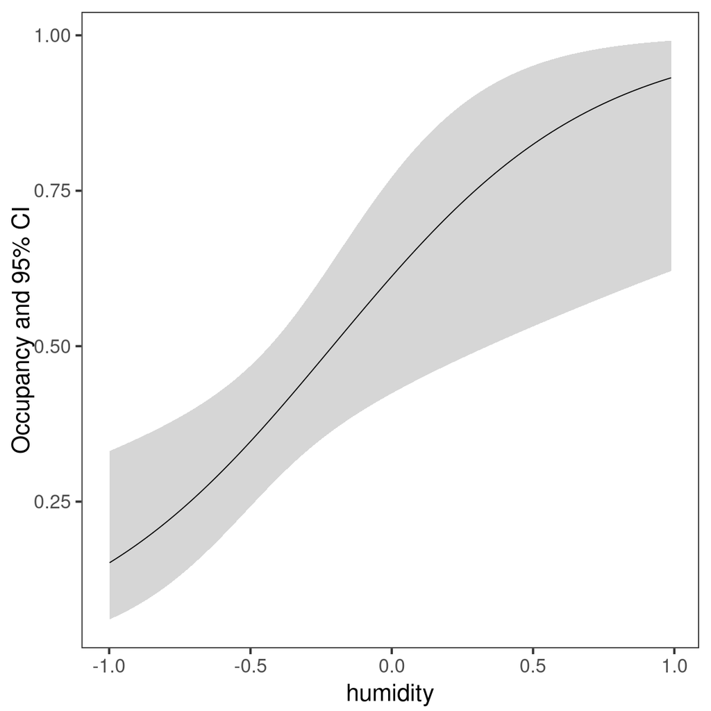

```r
ggplot(data = pr, aes(x=humidity)) +
  geom_ribbon(aes(ymin=lower, ymax=upper), alpha = 0.2) +
  geom_line(aes(y=Predicted)) +
  theme_bw(base_size=24) +
  theme(panel.grid = element_blank()) +
  labs(y = "Occupancy and 95% CI")
```

**Using `plotEffects`**

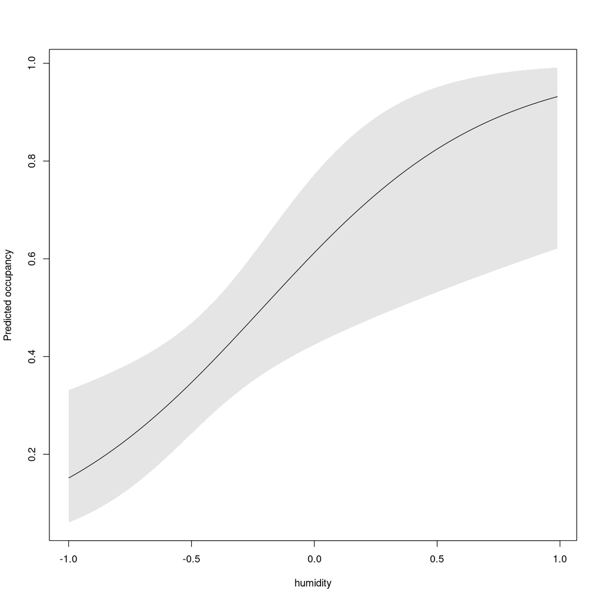

```r
plotEffects(fit_unm, type='state', covariate='humidity')
```

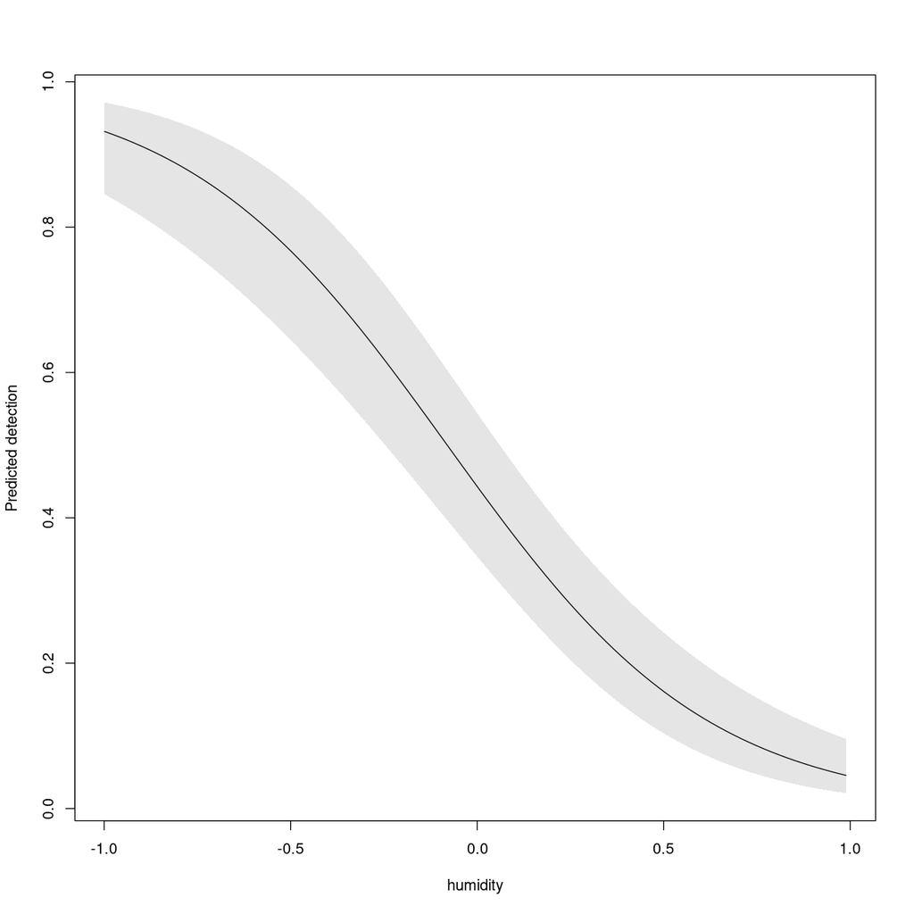

```r
plotEffects(fit_unm, type='det', covariate='humidity')
```

### Estimate total number of occupied sites

The `ranef` function: uses empirical Bayes to to estimate posterior distribution of $z$

```r
r <- ranef(fit_unm)
round(sum(bup(r)), 2)
```

87.83

## Model selection

First fit another (null) model

```r
fit_null <- occu(~1~1, umf)
```

Combine the models into a `fitList`

```r
fits <- fitList(hum=fit_unm, null=fit_null)
```

Get AIC model selection table

```r
modSel(fits)
```

```
     nPars    AIC delta   AICwt cumltvWt
hum      4 356.45  0.00 1.0e+00     1.00
null     2 394.78 38.33 4.8e-09     1.00
```

## NIMBLE

Workflow:

1. Bundle the data
2. Write the BUGS code
3. Set initial values
4. Run with `nimbleMCMC`
5. Diagnostics
6. Inference

```r
library(nimble)
```

## Bundle the data

```r
data_list <- list(nsites = nsites, nvisits = nvisits, y = y, humidity = humidity)
str(data_list)
```

```
List of 4
 $ nsites  : num 150
 $ nvisits : num 3
 $ y       : int [1:150, 1:3] 0 0 0 0 0 0 0 0 1 0 ...
 $ humidity: num [1:150] -0.425 0.577 -0.182 0.766 0.881 ...
```

## Write the BUGS code

### State model

**Math**

$$\mu_{occ_i} = \mathrm{occ}_{int} + \mathrm{occ}_{hum} \cdot \mathrm{humidity_i} $$

$$\psi_i = \mathrm{expit}(\mu_{occ_i})$$

$$z_i \sim \mathrm{Bernoulli}(\psi_i)$$

```
for (i in 1:nsites){
  mu_occ[i] <- occ_int + occ_hum * humidity[i]
  psi[i] <- expit(mu_occ[i])
  z[i] ~ dbern(psi[i])
}
```

### Detection model

**Math**

$$ \mu_{det_i} = \mathrm{det}_{int} + \mathrm{det}_{hum} \cdot \mathrm{humidity_i} $$

$$ p_i = \mathrm{expit}(\mu_{det_i}) $$

$$y_{ij} \sim \mathrm{Bernoulli}(p_i \cdot z_i)$$

**Code**

```
for (i in 1:nsites){
  mu_det[i] <- det_int + det_hum * humidity[i]
  p[i] <- expit(mu_det[i])

   for (j in 1:nvisits){
    y[i,j] ~ dbern(p[i] * z[i])
  }
}
```

### Number of occupied sites

**Math**

$$z_{sum} = \sum{z}$$

**Code**

```
zsum <- sum(z[1:nsites])
```

### Goodness-of-fit

We'll calculate SSE for the real dataset and for simulated datasets, same as with `parboot`.

**Math**

$$ \mathrm{SSE} = \sum\left(y_{ij} - \hat{y}_{ij}\right)^2 $$ $$ \hat{y}_{ij} = \psi_i \cdot p_{ij} $$

**Code**

```
for (i in 1:nsites){
  for (j in 1:nvisits){
    yhat[i,j] <- psi[i] * p[i]
    r2[i,j] <- (y[i,j] - yhat[i,j])^2

    # New dataset
    y_new[i,j] ~ dbern(p[i] * z[i])
    r2_new[i,j] <- (y_new[i,j] - yhat[i,j])^2
  }
}
SSE <- sum(r2[1:nsites, 1:nvisits])
SSE_new <- sum(r2_new[1:nsites, 1:nvisits])
```

```r
code_occu <- nimbleCode({
  # State model
  for (i in 1:nsites){
    mu_occ[i] <- occ_int + occ_hum * humidity[i]
    psi[i] <- expit(mu_occ[i])
    z[i] ~ dbern(psi[i])
  }

  # Detection model
  for (i in 1:nsites){
    mu_det[i] <- det_int + det_hum * humidity[i]
    p[i] <- expit(mu_det[i])

    for (j in 1:nvisits){
      y[i,j] ~ dbern(p[i] * z[i])
    }
  }

  # Number of occupied sites
  zsum <- sum(z[1:nsites])

  # Priors
  occ_int ~ dunif(-5, 5)
  occ_hum ~ dnorm(0, sd = 10)

  det_int ~ dunif(-5, 5)
  det_hum ~ dnorm(0, sd = 10)

  # GOF
  for (i in 1:nsites){
    for (j in 1:nvisits){
      yhat[i,j] <- psi[i] * p[i]
      r2[i,j] <- (y[i,j] - yhat[i,j])^2

      # New dataset
      y_new[i,j] ~ dbern(p[i] * z[i])
      r2_new[i,j] <- (y_new[i,j] - yhat[i,j])^2
    }
  }
  SSE <- sum(r2[1:nsites, 1:nvisits])
  SSE_new <- sum(r2_new[1:nsites, 1:nvisits])
})
```

Quick test run:

```r
fit_nim <- nimbleMCMC(code_occu, constants = data_list,
                       nchain = 4, niter = 300, nburnin = 100, samplesAsCodaMCMC = TRUE)
```

[output not shown]

[output not shown]

```
running chain 2...
```

```
|-------------|-------------|-------------|-------------|
|-------------------------------------------------------|
```

```
running chain 3...
```

```
|-------------|-------------|-------------|-------------|
|-------------------------------------------------------|
```

```
running chain 4...
```

```
|-------------|-------------|-------------|-------------|
|-------------------------------------------------------|
```

### Initial values

**Issue**: need to initialize `z` at some reasonable values

Initialize at the maximum observation (i.e., `z = 1` if species was observed at least once)

```r
inits <- function() list(z = apply(y, 1, max)) # same as y_naive
```

### Fit the model

```r
fit_nim <- nimbleMCMC(code_occu,
                      constants = data_list,
                      inits = inits,
                      monitors = c("occ_int","occ_hum","det_int","det_hum","zsum", "SSE", "SSE_new"),
                      nchain = 4,
                      niter = 2000,
                      nburnin = 1000,
                      samplesAsCodaMCMC = TRUE)
```

[output not shown]

```
|-------------|-------------|-------------|-------------|
|-------------------------------------------------------|
```

```
running chain 2...
```

[output not shown]

```
running chain 3...
```

[output not shown]

```
running chain 4...
```

[output not shown]

```r
lapply(fit_nim, head)
```

```
$chain1
Markov Chain Monte Carlo (MCMC) output:
Start = 1
End = 7
Thinning interval = 1
          SSE  SSE_new   det_hum    det_int  occ_hum   occ_int zsum
[1,] 68.56955 69.65438 -3.082583 -0.1970474 2.604098 0.3457456   90
[2,] 68.54747 70.37775 -2.799447 -0.1970474 2.604098 0.3770824   89
[3,] 68.54747 64.86814 -2.799447 -0.1970474 2.604098 0.3770824   93
[4,] 68.56096 76.63553 -2.799447 -0.1970474 2.840499 0.9662541   93
[5,] 68.65507 68.57751 -2.645548 -0.1970474 3.031188 0.8937312   91
[6,] 68.65476 72.30196 -2.645548 -0.1970474 3.031188 0.8912387   95
[7,] 68.49411 65.94895 -2.936696 -0.1970474 2.926537 0.8912387   90

$chain2
Markov Chain Monte Carlo (MCMC) output:
Start = 1
End = 7
Thinning interval = 1
          SSE  SSE_new   det_hum    det_int  occ_hum   occ_int zsum
[1,] 68.46815 65.61864 -2.908988 -0.2749741 3.017031 0.7524614   90
[2,] 68.49383 66.40404 -2.908988 -0.2749741 3.017031 0.7332511   93
[3,] 68.70891 68.26045 -2.498150 -0.2556544 3.017031 0.7332511   94
[4,] 68.54207 64.04466 -2.790937 -0.2556544 3.017031 0.7332511   93
[5,] 68.83871 70.77927 -3.046688 -0.1307382 3.017031 0.5957714   91
[6,] 68.83871 63.76215 -3.046688 -0.1307382 3.017031 0.5957714   93
[7,] 68.90156 65.06583 -3.635834 -0.1307382 3.017031 0.5957714   89

$chain3
Markov Chain Monte Carlo (MCMC) output:
Start = 1
End = 7
Thinning interval = 1
          SSE  SSE_new   det_hum     det_int  occ_hum   occ_int zsum
[1,] 68.31396 71.31233 -3.346780 -0.08707311 2.518776 0.4350399   86
[2,] 68.12256 65.43935 -3.346780 -0.08707311 2.284929 0.4350399   90
[3,] 68.15253 64.38130 -3.346780 -0.37600544 2.284929 0.4350399   90
[4,] 68.56693 58.29958 -2.739612 -0.39585189 2.685536 0.4775243   90
[5,] 69.50967 78.38962 -2.714176  0.09808932 2.685536 0.7386098   91
[6,] 69.59631 79.35679 -2.714176  0.09808932 2.685536 0.7682890   90
[7,] 68.29620 73.35753 -2.714176 -0.18725190 2.685536 0.7682890   94

$chain4
Markov Chain Monte Carlo (MCMC) output:
Start = 1
End = 7
Thinning interval = 1
          SSE  SSE_new   det_hum    det_int  occ_hum  occ_int zsum
[1,] 68.80462 61.17245 -2.955600 -0.5047956 3.805975 1.242024   97
[2,] 69.34674 66.77224 -2.955600 -0.5047956 4.098343 1.242024  100
[3,] 69.79924 63.69246 -2.955600 -0.5047956 4.098343 1.065204   98
[4,] 70.46461 65.38244 -2.458803 -0.5047956 4.302729 1.065204   98
[5,] 70.45116 72.31247 -2.458803 -0.5047956 4.297018 1.065204   97
[6,] 70.45794 71.67292 -3.391717 -0.2548212 4.297018 1.064808  102
[7,] 70.46695 71.94776 -2.982624 -0.2548212 4.297018 1.064808   98
```

### Diagnostics

**Traceplots:**

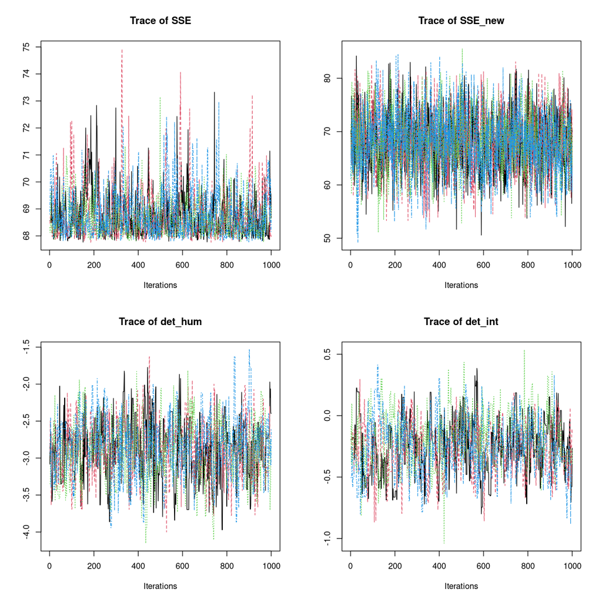

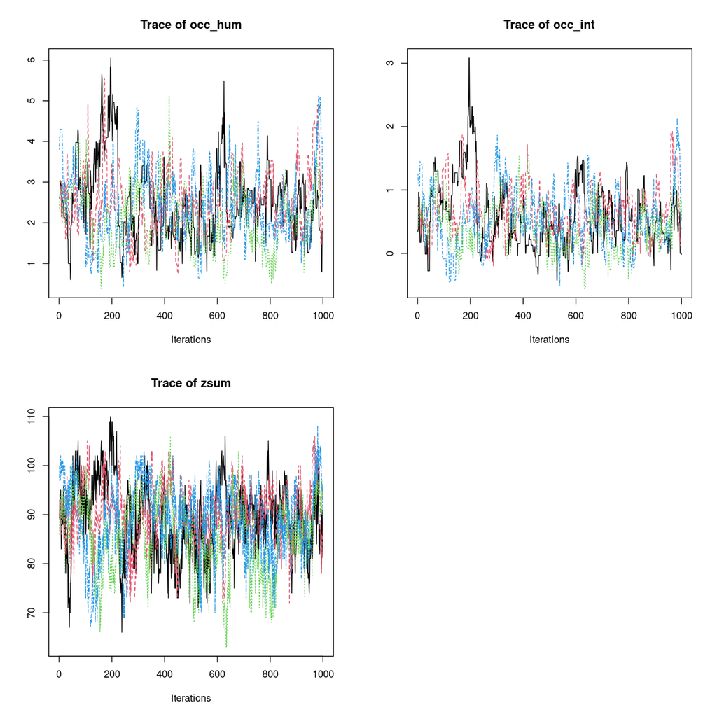

```r
par(mfrow=c(2,2))
coda::traceplot(fit_nim)
```

**Rhat:**

```r
coda::gelman.diag(fit_nim)
```

```
Potential scale reduction factors:

        Point est. Upper C.I.
SSE           1.03       1.08
SSE_new       1.00       1.01
det_hum       1.00       1.01
det_int       1.06       1.17
occ_hum       1.08       1.23
occ_int       1.11       1.31
zsum          1.14       1.37

Multivariate psrf

1.12
```

**Effective samples:**

```r
round(coda::effectiveSize(fit_nim))
```

**SSE**

698

**SSE_new**

1576

**det_hum**

685

**det_int**

426

**occ_hum**

131

**occ_int**

136

**zsum**

149

**Posterior predictive check**

Compare SSE for real and simulated datasets

Similar to what `parboot` did

```r
samples <- as.data.frame(as.matrix(fit_nim))
head(samples)
```

A data.frame: 6 × 7

|  | SSE <dbl> | SSE_new <dbl> | det_hum <dbl> | det_int <dbl> | occ_hum <dbl> | occ_int <dbl> | zsum <dbl> |
| --- | --- | --- | --- | --- | --- | --- | --- |
| 1 | 68.56955 | 69.65438 | -3.082583 | -0.1970474 | 2.604098 | 0.3457456 | 90 |
| 2 | 68.54747 | 70.37775 | -2.799447 | -0.1970474 | 2.604098 | 0.3770824 | 89 |
| 3 | 68.54747 | 64.86814 | -2.799447 | -0.1970474 | 2.604098 | 0.3770824 | 93 |
| 4 | 68.56096 | 76.63553 | -2.799447 | -0.1970474 | 2.840499 | 0.9662541 | 93 |
| 5 | 68.65507 | 68.57751 | -2.645548 | -0.1970474 | 3.031188 | 0.8937312 | 91 |
| 6 | 68.65476 | 72.30196 | -2.645548 | -0.1970474 | 3.031188 | 0.8912387 | 95 |

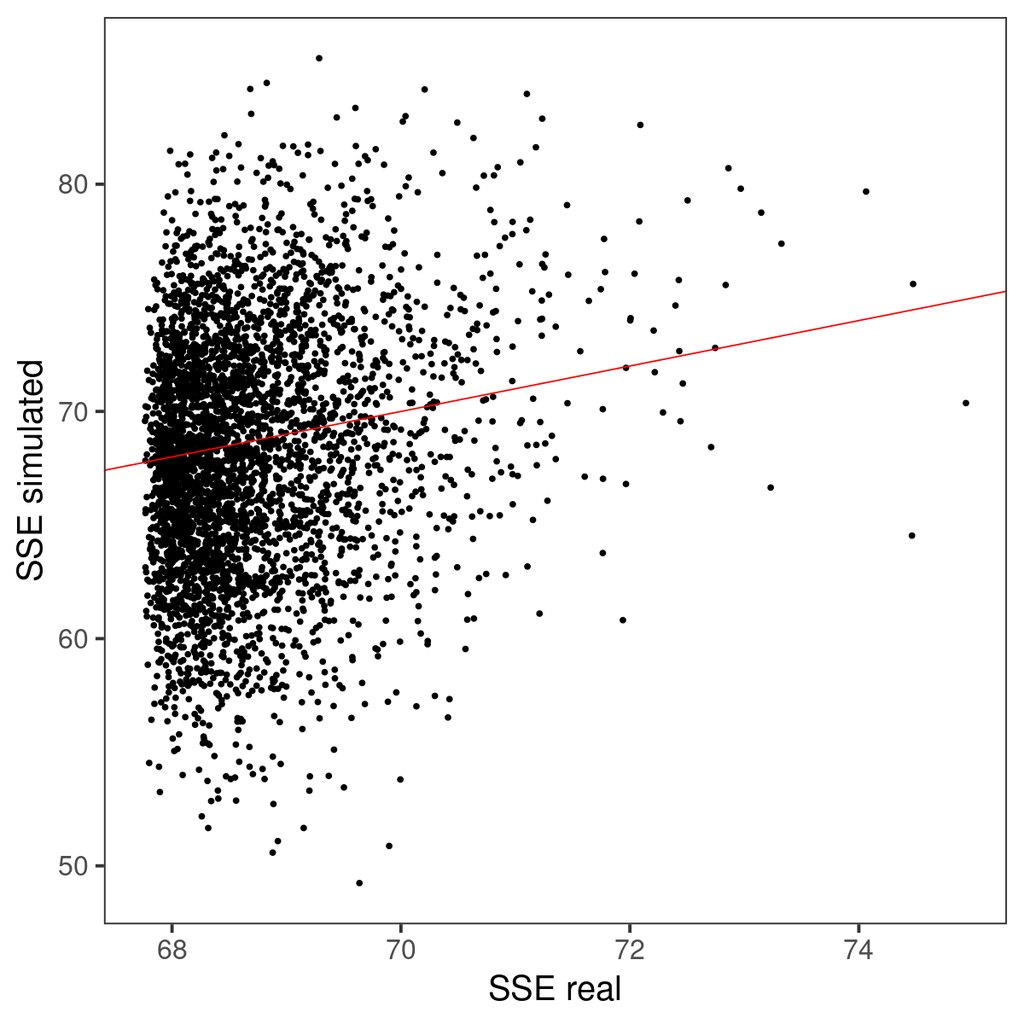

```r
ggplot(data = samples) +
  geom_point(aes(x=SSE, y=SSE_new)) +
  geom_abline(col = "red") +
  theme_bw(base_size = 24) +
  theme(panel.grid = element_blank()) +
  labs(x = "SSE real", y = "SSE simulated")
```

**Bayesian p-value**

- Essentially the proportion of points above/below the line
- Ideally should be ~0.5
- Values close to 0 or 1 indicate poor fit

```r
mean(samples$SSE > samples$SSE_new)
```

0.5325

## Inference

```r
summary(fit_nim)
```

```
Iterations = 1:1000
Thinning interval = 1
Number of chains = 4
Sample size per chain = 1000

1. Empirical mean and standard deviation for each variable,
   plus standard error of the mean:

           Mean     SD Naive SE Time-series SE
SSE     68.6955 0.7895 0.012483        0.03253
SSE_new 68.2122 5.3955 0.085310        0.13622
det_hum -2.8770 0.3883 0.006139        0.01511
det_int -0.2389 0.2155 0.003408        0.01080
occ_hum  2.3824 0.8399 0.013279        0.07434
occ_int  0.5577 0.4436 0.007014        0.03870
zsum    88.3515 7.2422 0.114510        0.61868

2. Quantiles for each variable:

           2.5%     25%     50%      75%    97.5%
SSE     67.8698 68.1355 68.4731 69.02954  70.7812
SSE_new 57.7234 64.6313 68.1654 71.92533  78.8302
det_hum -3.6548 -3.1434 -2.8597 -2.61277  -2.1196
det_int -0.6597 -0.3926 -0.2388 -0.09299   0.1837
occ_hum  0.9996  1.8143  2.3100  2.87400   4.3259
occ_int -0.1904  0.2435  0.5125  0.79346   1.5455
zsum    73.0000 84.0000 89.0000 93.00000 101.0000
```

Compare estimates:

```r
samps <- as.matrix(fit_nim)[,c("occ_int","occ_hum","det_int","det_hum")]
nim_est <- apply(samps, 2, mean)
```

```r
comp <- cbind(comp, nimble=nim_est)
round(comp, 3)
```

A matrix: 4 × 4 of type dbl

|  | truth | glm | unm | nimble |
| --- | --- | --- | --- | --- |
| occ_int | 0 | -0.663 | 0.457 | 0.558 |
| occ_hum | 2 | -0.129 | 2.181 | 2.382 |
| det_int | 0 | NA | -0.228 | -0.239 |
| det_hum | -3 | NA | -2.844 | -2.877 |

**Make a plot of humidity effect on occupancy**

**Math**

$$\mu_{occ_i} = \mathrm{occ}_{int} + \mathrm{occ}_{hum} \cdot \mathrm{humidity_i} $$

$$\psi_i = \mathrm{ilogit}(\mu_{occ_i})$$

**Code**

```
for (i in 1:n_hum_values){
  mu_occ[i] <- occ_int + occ_hum * hum_values[i]
  psi[i] <- plogis(mu_occ[i])
}
```

**Values of humidity**

```r
hum_seq <- seq(min(humidity), max(humidity), length.out=100)
```

**Posteriors of `occ_int` and `occ_hum`**

```r
samps <- as.matrix(fit_nim)
head(samps)
```

A matrix: 6 × 7 of type dbl

| SSE | SSE_new | det_hum | det_int | occ_hum | occ_int | zsum |
| --- | --- | --- | --- | --- | --- | --- |
| 68.56955 | 69.65438 | -3.082583 | -0.1970474 | 2.604098 | 0.3457456 | 90 |
| 68.54747 | 70.37775 | -2.799447 | -0.1970474 | 2.604098 | 0.3770824 | 89 |
| 68.54747 | 64.86814 | -2.799447 | -0.1970474 | 2.604098 | 0.3770824 | 93 |
| 68.56096 | 76.63553 | -2.799447 | -0.1970474 | 2.840499 | 0.9662541 | 93 |
| 68.65507 | 68.57751 | -2.645548 | -0.1970474 | 3.031188 | 0.8937312 | 91 |
| 68.65476 | 72.30196 | -2.645548 | -0.1970474 | 3.031188 | 0.8912387 | 95 |

**Calculate posterior of `mu` for each value of humidity**

```r
mu_post <- matrix(NA, nrow=nrow(samps), ncol = 100)

for (i in 1:100){
  mu_post[,i] <- samps[,"occ_int"] + samps[,"occ_hum"] * hum_seq[i]
}
```

```r
psi_post <- plogis(mu_post)
```

**Calculate mean psi and 95% CI at each value of humidity**

```r
psi_mean <- apply(psi_post, 2, mean)
psi_lower <- apply(psi_post, 2, quantile, 0.025)
psi_upper <- apply(psi_post, 2, quantile, 0.975)
```

**Make plot**

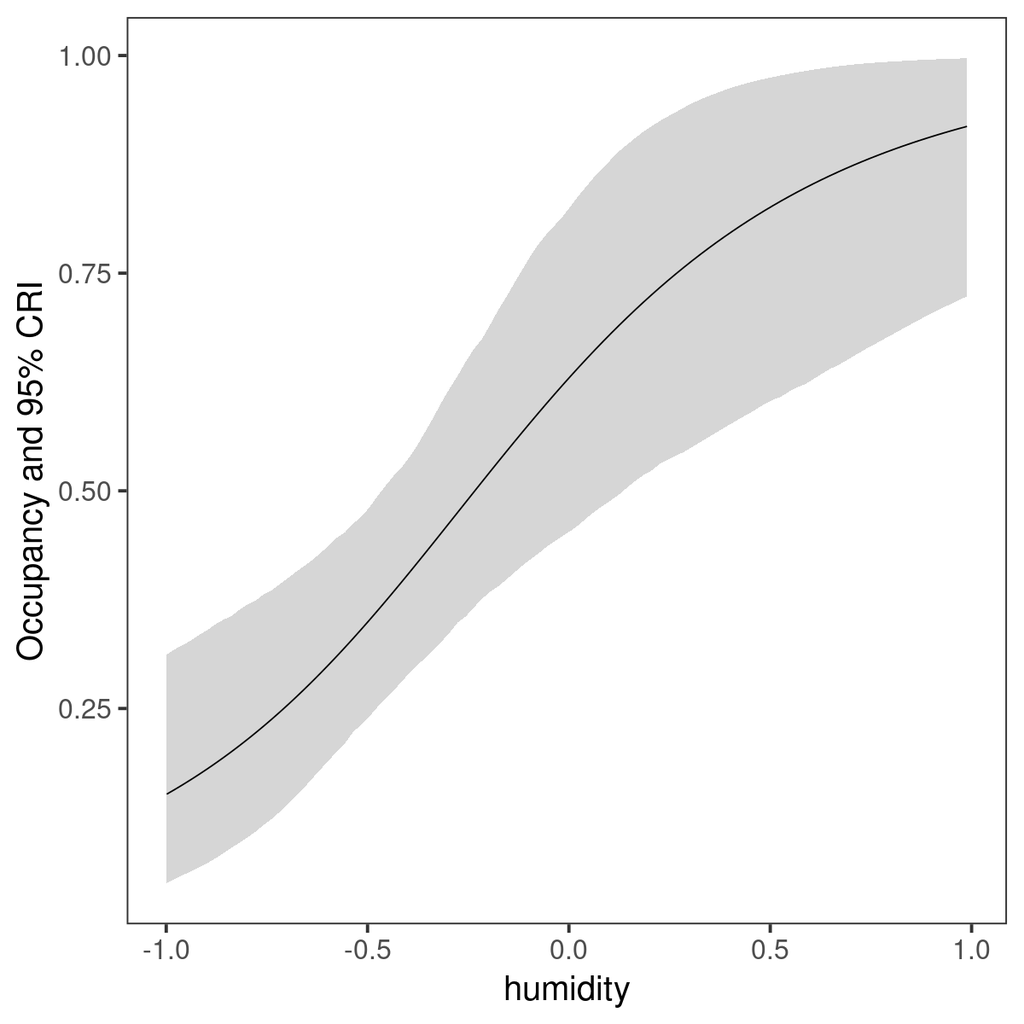

```r
plot_dat <- data.frame(humidity = hum_seq, est=psi_mean, lower=psi_lower, upper=psi_upper)

ggplot(data=plot_dat, aes(x=humidity)) +
  geom_ribbon(aes(ymin=lower, ymax=upper), alpha=0.2) +
  geom_line(aes(y=est)) +
  theme_bw(base_size=24) +
  theme(panel.grid=element_blank()) +
  labs(y = "Occupancy and 95% CRI")
```

### Exercise: modifying the model

- Simulate a new site-level covariate and add it to the model
- Plot its effect if you have time

# Bonus content: Occupancy macro in `nimble`

Macros are an in-development feature in `nimble`

They are "shortcut" code chunks which are expanded into larger blocks of model code.

```r
library(nimbleEcology) # development version
nimbleOptions(enableModelMacros = TRUE)
```

```
Loading nimbleEcology. Registering the following distributions:
 dOcc, dDynOcc, dCJS, dHMM, dDHMM, dNmixture.
```

```r
code <- nimbleCode({
  y[1:nsites, 1:nvisits] ~ occupancy(~humidity[1:nsites], ~humidity[1:nsites])
})
```

```r
mod <- nimbleModel(code, constants = data_list)
mod$getCode()
```

```
Defining model

  [Note] 'newcov' is provided in 'constants' but not used in the model code and is being ignored.


  [Note] Using 'y' (given within 'constants') as data.

Building model

Setting data and initial values

Running calculate on model
  [Note] Any error reports that follow may simply reflect missing values in model variables.

Checking model sizes and dimensions

  [Note] This model is not fully initialized. This is not an error.
         To see which variables are not initialized, use model$initializeInfo().
         For more information on model initialization, see help(modelInitialization).
```

```
{
    "# occupancy"
    "  ## nimbleMacros::linPred"
    "    ### nimbleMacros::forLoop"
    for (i_1 in 1:nsites) {
        logit(psi[i_1]) <- state_Intercept + state_humidity *
            humidity[i_1]
    }
    "    ### ----"
    "    ### nimbleMacros::priors"
    state_Intercept ~ dunif(-10, 10)
    state_humidity ~ dlogis(0, 1)
    "    ### ----"
    "  ## ----"
    "  ## nimbleMacros::linPred"
    "    ### nimbleMacros::forLoop"
    for (i_2 in 1:nsites) {
        for (i_3 in 1:nvisits) {
            logit(p[i_2, i_3]) <- det_Intercept + det_humidity *
                humidity[i_2]
        }
    }
    "    ### ----"
    "    ### nimbleMacros::priors"
    det_Intercept ~ dunif(-10, 10)
    det_humidity ~ dlogis(0, 1)
    "    ### ----"
    "  ## ----"
    "  ## nimbleMacros::forLoop"
    for (i_4 in 1:nsites) {
        z[i_4] ~ dbern(psi[i_4])
    }
    "  ## ----"
    "  ## nimbleMacros::forLoop"
    for (i_5 in 1:nsites) {
        for (i_6 in 1:nvisits) {
            y[i_5, i_6] ~ dbern(p[i_5, i_6] * z[i_5])
        }
    }
    "  ## ----"
    "# ----"
}
```

# Bonus content: `ubms`

Fit Bayesian occupancy models using samed syntax as `unmarked`.

Just need to change `occu` to `stan_occu`

```r
library(ubms)
fit_ubms <- stan_occu(~humidity ~humidity, data = umf)
```

```r
fit_ubms
```

```
Call:
stan_occu(formula = ~humidity ~ humidity, data = umf)

Occupancy (logit-scale):
            Estimate    SD   2.5% 97.5% n_eff Rhat
(Intercept)    0.321 0.350 -0.297  1.07  1877    1
humidity       1.832 0.679  0.599  3.28  1909    1

Detection (logit-scale):
            Estimate    SD   2.5% 97.5% n_eff Rhat
(Intercept)   -0.198 0.207 -0.589  0.22  2387    1
humidity      -2.679 0.386 -3.442 -1.93  2953    1

LOOIC: 356.132
Runtime: 8.352 sec
```

```
'pars' not specified. Showing first 10 parameters by default.
```

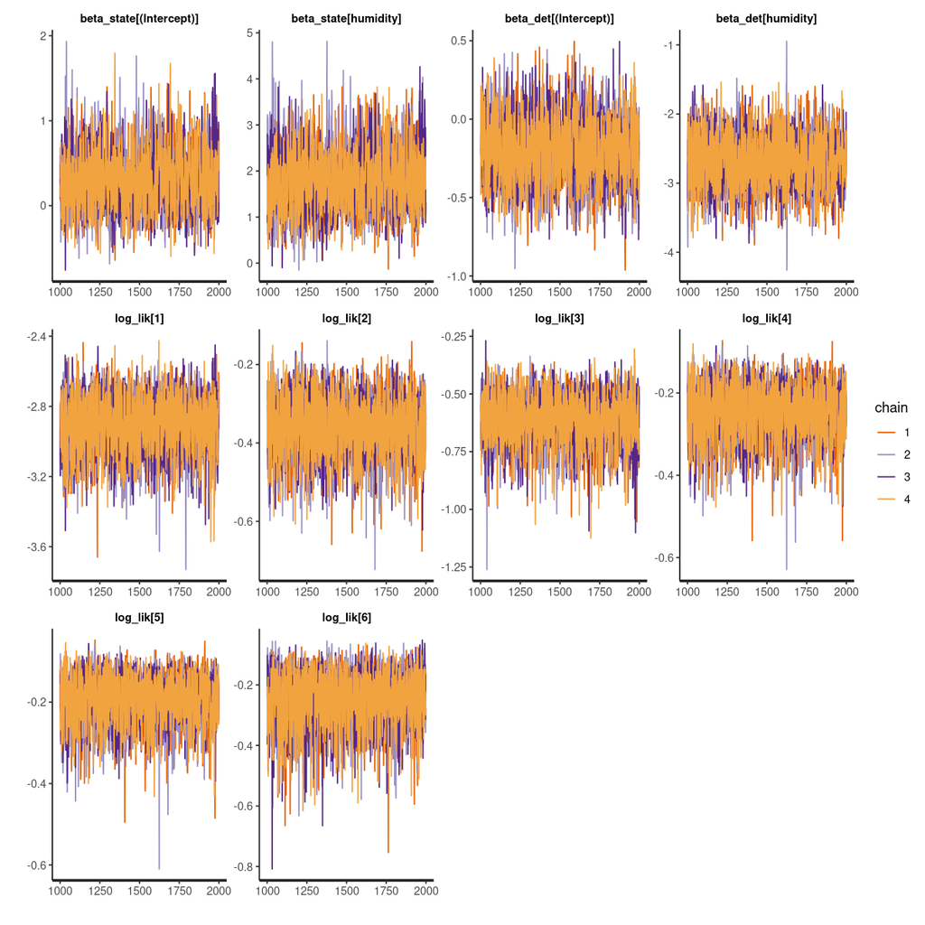

```r
traceplot(fit_ubms)
```

**Residuals**

Separated by occupancy and detection process

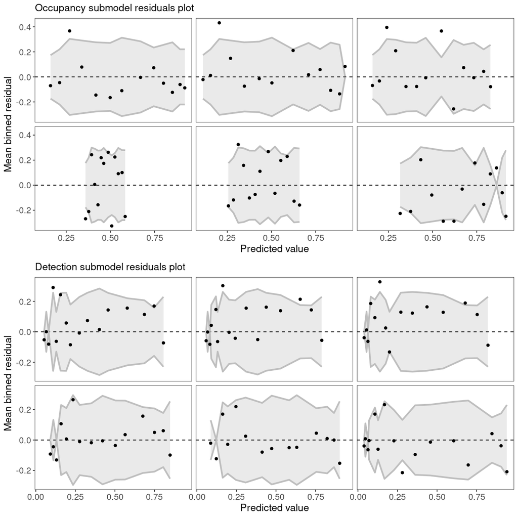

```r
plot(fit_ubms)
```

**Goodness of fit with posterior predictive check**

- Uses the specialized MacKenzie-Bailey chi-square test for occupancy models
- This test compares the expected frequencies of encounter histories given the model ([001] [110] and so on) with what we actually observed
- We calculate MB statistic for real dataset and for simulated datasets and compare

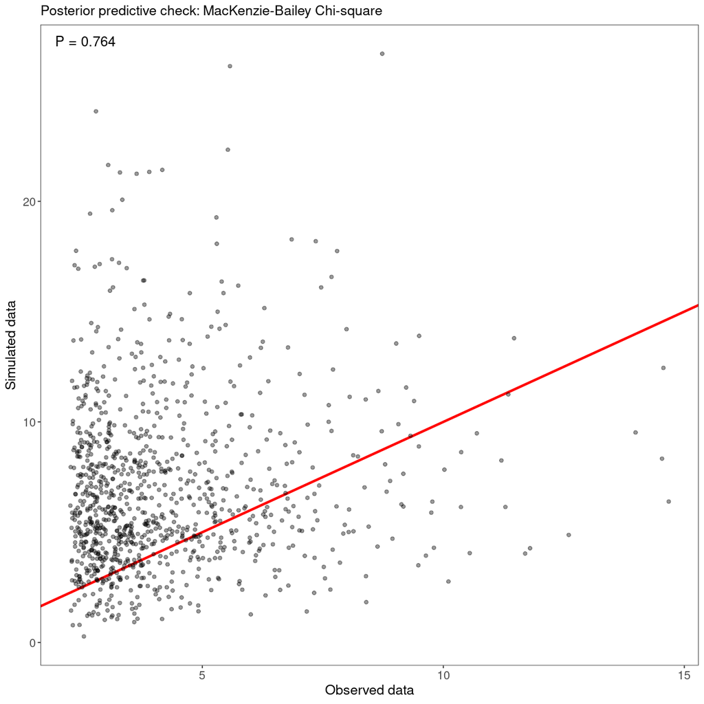

```r
g <- gof(fit_ubms, draws = 1000)
plot(g)
```

Extract full posterior distributions:

```r
post <- extract(fit_ubms)
lapply(post, head)
```

**$beta_state**

A matrix: 6 × 2 of type dbl

| 0.193040403 | 2.614001 |
| --- | --- |
| -0.018344069 | 1.457307 |
| 0.792506112 | 3.094346 |
| 0.606949762 | 1.971397 |
| -0.006172756 | 1.511970 |
| 0.593725436 | 2.019312 |

**$beta_det**

A matrix: 6 × 2 of type dbl

| -0.2935416 | -2.357607 |
| --- | --- |
| -0.1258090 | -2.520538 |
| -0.1751919 | -3.476876 |
| -0.1560915 | -2.998728 |
| -0.2641516 | -2.269473 |
| -0.3057500 | -2.085874 |

**$log_lik**

A matrix: 6 × 150 of type dbl

| -3.163247 | -0.4241387 | -0.4881384 | -0.3060378 | -0.2448509 | -0.1065300 | -0.6067170 | -0.2953797 | -2.942589 | -0.5473986 | ⋯ | -0.3535988 | -0.4888056 | -0.08953519 | -2.460475 | -2.452767 | -3.407840 | -2.433115 | -0.1240769 | -0.2707547 | -0.4968101 |
| --- | --- | --- | --- | --- | --- | --- | --- | --- | --- | --- | --- | --- | --- | --- | --- | --- | --- | --- | --- | --- |
| -2.991908 | -0.3549144 | -0.5079978 | -0.2577963 | -0.2071292 | -0.2316955 | -0.5483711 | -0.2490017 | -2.956787 | -0.5337298 | ⋯ | -0.4332794 | -0.5083176 | -0.21148844 | -1.891635 | -2.608723 | -3.171483 | -1.953732 | -0.2509821 | -0.3774463 | -0.4154360 |
| -3.011618 | -0.2948730 | -0.7436661 | -0.1630594 | -0.1119474 | -0.1245613 | -0.8542764 | -0.1534270 | -2.735755 | -0.8290388 | ⋯ | -0.5141334 | -0.7447376 | -0.10144154 | -1.808329 | -2.835028 | -3.421075 | -1.718762 | -0.1491279 | -0.3747822 | -0.4077580 |
| -2.781659 | -0.3483194 | -0.7438668 | -0.2178152 | -0.1606172 | -0.2667050 | -0.7779778 | -0.2073947 | -2.760033 | -0.7822143 | ⋯ | -0.6098530 | -0.7444002 | -0.23603647 | -1.548343 | -2.655389 | -3.029964 | -1.582218 | -0.2967350 | -0.5091801 | -0.4470518 |
| -2.978645 | -0.3624640 | -0.4901511 | -0.2746277 | -0.2267980 | -0.2236084 | -0.5264196 | -0.2664362 | -3.041413 | -0.5132126 | ⋯ | -0.4210470 | -0.4904399 | -0.20346324 | -2.096090 | -2.575591 | -3.116210 | -2.173926 | -0.2428387 | -0.3675896 | -0.4151353 |
| -2.747759 | -0.4855932 | -0.6815829 | -0.3637855 | -0.2995605 | -0.2524028 | -0.7382595 | -0.3526955 | -2.810656 | -0.7189768 | ⋯ | -0.5670387 | -0.6820573 | -0.22289845 | -2.021143 | -2.352260 | -2.883596 | -2.078865 | -0.2812081 | -0.4788514 | -0.5618213 |

**$lp__**

1. -184.992965256198

2. -182.558112016328

3. -185.607335703896

4. -183.122006171373

5. -183.112204995482

6. -184.218805760602

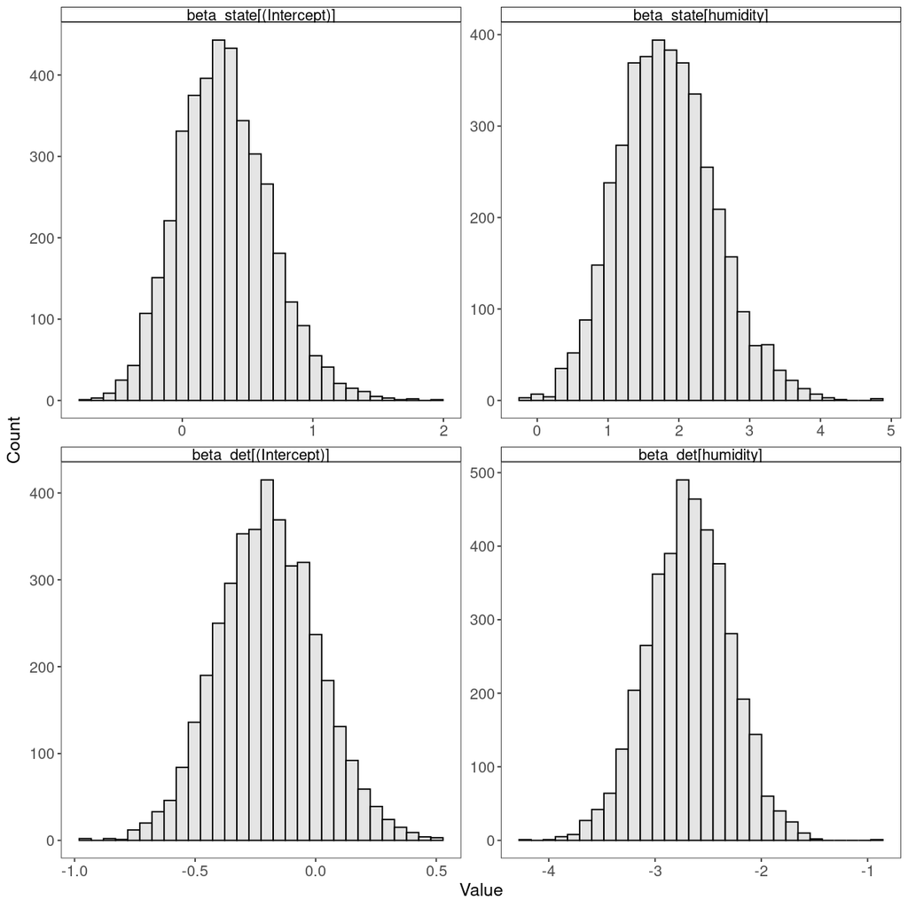

```r
plot_posteriors(fit_ubms)
```

Plot effects:

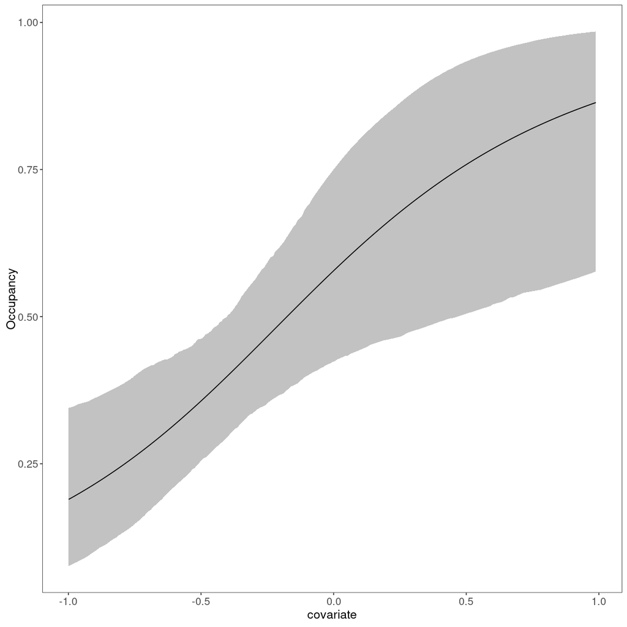

```r
plot_effects(fit_ubms, 'state')
```

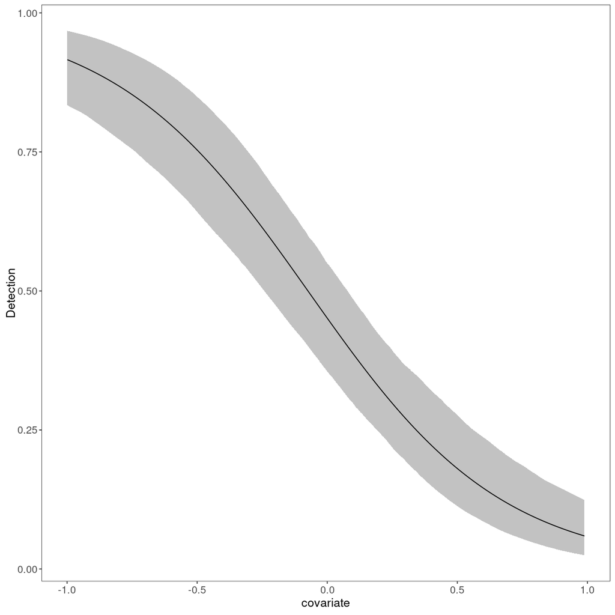

```r
plot_effects(fit_ubms, 'det')
```

**Estimate total occupied sites**

```r
zpost <- posterior_predict(fit_ubms, "z")
```

83.92475

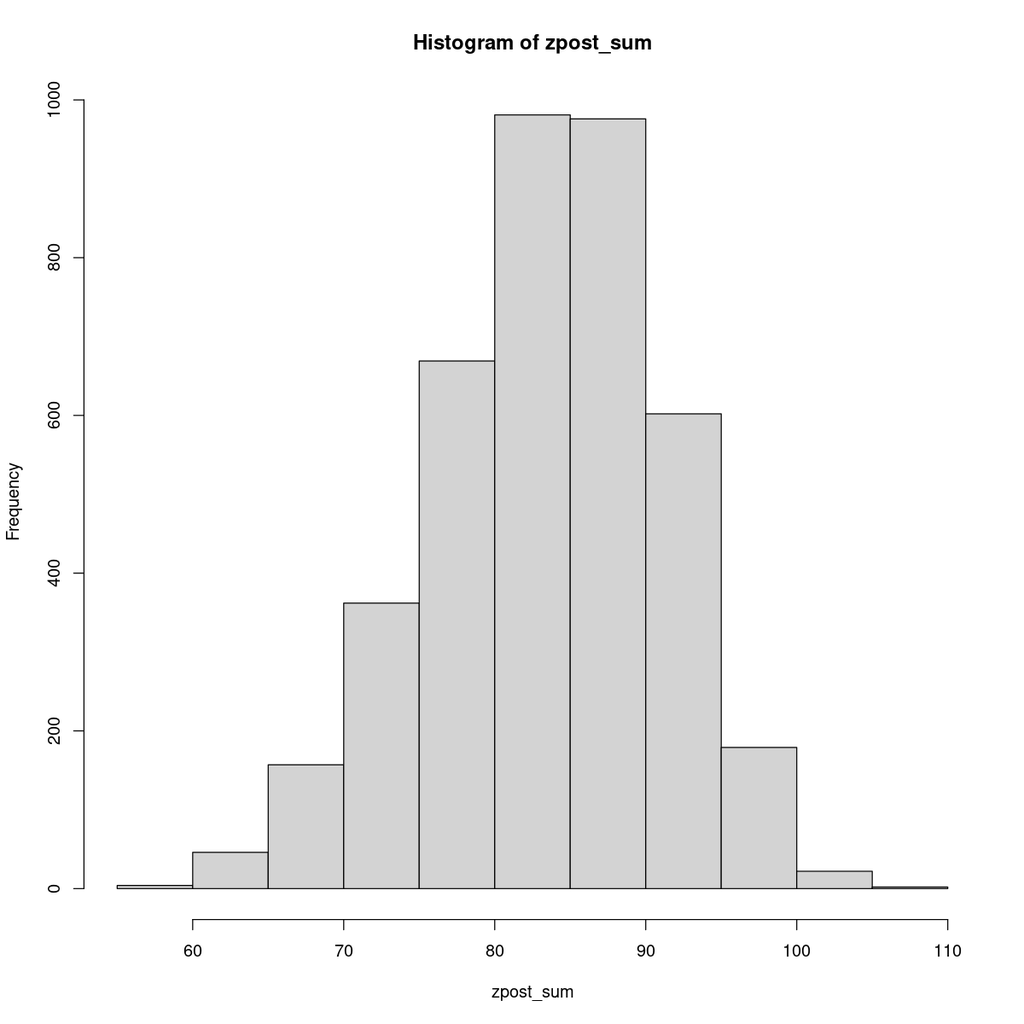

```r
zpost_sum <- apply(zpost, 1, sum)
mean(zpost_sum)
hist(zpost_sum)
```

**Information criterion**

```r
waic(fit_ubms)
```

```
Computed from 4000 by 150 log-likelihood matrix.

          Estimate   SE
elpd_waic   -178.1 14.1
p_waic         3.4  0.4
waic         356.1 28.3
```

```r
loo(fit_ubms) # approximation based on single fit
```

```
Computed from 4000 by 150 log-likelihood matrix.

         Estimate   SE
elpd_loo   -178.1 14.1
p_loo         3.4  0.4
looic       356.1 28.3
------
MCSE of elpd_loo is 0.0.
MCSE and ESS estimates assume MCMC draws (r_eff in [0.4, 1.3]).

All Pareto k estimates are good (k < 0.7).
See help('pareto-k-diagnostic') for details.
```

```r
kfold(fit_ubms, K=5) # actual real cross-validation
```

```
Computed from 4000 by 150 log-likelihood matrix using the generic elpd function

     Estimate   SE
elpd   -179.1 14.3
ic      358.3 28.7
```

**Model selection**

```r
ubms_null <- stan_occu(~1~1, umf)
```

```r
fl <- fitList(null=ubms_null, hum=fit_ubms)
```

Use LOO-CV (approximation) for model selection

```r
modSel(fl)
```

A data.frame: 2 × 5

|  | elpd <dbl> | nparam <dbl> | elpd_diff <dbl> | se_diff <dbl> | weight <dbl> |
| --- | --- | --- | --- | --- | --- |
| hum | -178.0661 | 3.420673 | 0.00000 | 0.000000 | 1.00000e+00 |
| null | -197.5510 | 2.258432 | -19.48482 | 4.965189 | 1.22604e-08 |

`ubms` supports spatial random effects via RSR (restricted spatial regression) - see vignette.

Another very useful package, particularly for multispecies/spatial analyses: `spOccupancy`

# Bonus content: "Do it yourself" Maximum Likelihood

We need to calculate the marginal or integrated likelihood (i.e., "integrating out" the latent occupancy states at each site $z$)

**Two possible situations we observe:**

1. The species was detected at least once at site $i$
2. The species was never detected at site $i$

**If the species was detected at least once at site $i$:**

We know the species is present at the site ($z = 1$).

The likelihood is the product of the probability of occupancy * likelihood of detection process

$$L_i = \psi \cdot \mathrm{dbinom}(n_i, J, p)$$

Here $n_i$ is the number of times the species was detected in J samples

For example an encounter history [01010] would have $J = 5$ and $n = 2$

Or if $p$ varies with detection period $j$, we split the binomial into a series of Bernoullis and multiply them:

$$L_i = \psi \cdot \prod_{j=1}^J\mathrm{dbinom}(y_{ij}, 1, p_i)$$

**If the species was not detected at site $i$:**

Either

1. $z = 1$ (species present but undetected)
2. $z = 0$ (species not present)

We calculate the likelhood for each possibility and add them together.

1. $\psi \cdot \mathrm{dbinom}(n_i, J, p)$
2. $(1 - \psi)$

$$ L_i = \psi \cdot \mathrm{dbinom}(n_i, J, p) + (1-\psi)$$

**In summary:**

$$ L_i = \begin{cases} \psi \cdot \mathrm{dbinom}(n_i, J, p), & any\ detection \\ \psi \cdot \mathrm{dbinom}(n_i, J, p) + (1-\psi), & no detection \\ \end{cases} $$

or

$$L_i = \psi \cdot \mathrm{dbinom}(n_i, J, p) + (1-\psi) \cdot (\mathrm{no\_detects} == 1)$$

Need to add new data ($n$ and $\mathrm{no\_detects}$) to our list

```r
data_list$n <- apply(y, 1, sum)
data_list$no_detects <- 1 - apply(y, 1, max)
data_list$y <- NULL
str(data_list)
```

```
List of 6
 $ nsites    : num 150
 $ nvisits   : num 3
 $ humidity  : num [1:150] -0.425 0.577 -0.182 0.766 0.881 ...
 $ newcov    : num [1:150] 0.448 -2.233 0.921 -0.335 1.078 ...
 $ n         : int [1:150] 2 0 0 0 0 0 0 0 2 0 ...
 $ no_detects: num [1:150] 0 1 1 1 1 1 1 1 0 1 ...
```

**Math:**

$$L_i = \psi \cdot \mathrm{dbinom}(n_i, J, p) + (1-\psi) \cdot (\mathrm{no\_detects} == 1)$$

**Code:**

```
lik[i] <- psi[i] * dbinom(data$n[i], data$nvisits, p[i]) +
          (1 - psi[i]) * data$no_detects[i]
```

```r
NLL <- function(pars, data){
  occ_int <- pars[1]
  occ_hum <- pars[2]
  det_int <- pars[3]
  det_hum <- pars[4]

  # Calculate occupancy probability
  mu_occ <- occ_int + occ_hum * data$humidity
  psi <- plogis(mu_occ)

  # Calculate detection probability
  mu_det <- det_int + det_hum * data$humidity
  p <- plogis(mu_det)

  lik <- rep(0, data$nsites)
  for (i in 1:data$nsites){
    lik[i] <- psi[i] * dbinom(data$n[i], data$nvisits, p[i]) +
      (1 - psi[i]) * data$no_detects[i]
  }
  ll <- log(lik)
  return(-sum(ll))
}
```

```r
par_start <- c(occ_int = 0, occ_hum = 0, det_int = 0, det_hum = 0)
occ_diy <- optim(par_start, fn = NLL, hessian = TRUE, data = data_list)
```

```r
occ_diy$par
```

**occ_int**

0.457657812418837

**occ_hum**

2.1819903226228

**det_int**

-0.228274682489784

**det_hum**

-2.8431800815102